# Analyzing Google Search History

CME Group Foundation Business Analytics Lab

Jose Luis Rodriguez

January 30, 2018

## About this Notebook

- The google search data on this notebook comes from a google account archive
- The steps outlined here to collect and analyze the data may change at any time
- Below are the steps to claim your google account data

## Analytics Toolkit: Require Packages

**Install required packages**

- Package: tidyverse, lubridate, rvest, tm, wordcloud

```r
install.packages(c("rvest",
                   "lubridate",
                   "wordcloud",
                   "tm"), dependencies = TRUE)
```

**Load required packages**

```r
library(tm)
library(rvest)
library(lubridate)
library(tidyverse)
library(wordcloud)
```

## Data Collection: Claiming your Google Search Data

#### 1) Sign into your google account, then Go to:

- https://myaccount.google.com/privacy

#### 2) Find the link to download your data archive or Go to:

- https://takeout.google.com/settings/takeout

[figure not shown]

#### 3) Select all Google products to create a complete archive of your data

[figure not shown]

#### 4) After selecting the products, choose the file type and max archive size to make sure that all your account data is archive

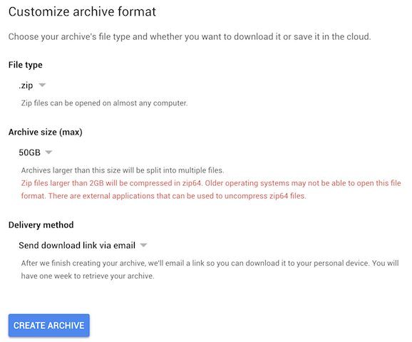

## Data Preparation: Extracting Google Search Information

#### Locate the Google archive, then find the search data. For this case, it is an html file located in “My Activity” folder inside the “Search” folder the file is named “MyActivity.html”

- Takeout -> My Activity -> Search -> MyActivity.html

#### Using the rvest package we can read the html document that contains the related google search data

```r
doc <- "Takeout/My Activity/Search/MyActivity.html"
search_archive <- read_html(doc)
```

### Laveraging regular expression (regex) we can extract relavant information from the HTML document:

#### Extract Search Time

```r
date_search <- search_archive %>%
  html_nodes(xpath = '//div[@class="mdl-grid"]/div/div') %>%
  str_extract(pattern = "(?<=<br>)(.*)(?<=PM|AM)") %>%
  mdy_hms()
```

```
 2 failed to parse.
```

#### Extract Search Text

```r
text_search <- search_archive %>%
  html_nodes(xpath = '//div[@class="mdl-grid"]/div/div') %>%
  str_extract(pattern = '(?<=<a)(.*)(?=</a>)') %>%
  str_extract(pattern = '(?<=\">)(.*)')
```

#### Extract Search Type

```r
type_search <- search_archive %>%
  html_nodes(xpath = '//div[@class="mdl-grid"]/div/div') %>%
  str_extract(pattern = "(?<=mdl-typography--body-1\">)(.*)(?=<a)") %>%
  str_extract(pattern = "(\\w+)(?=\\s)")
```

#### Create a data frame using the data extracted from the html file

```r
search_data <- tibble(timestamp = date_search,
                      date = as_date(date_search),
                      year = year(date_search),
                      month = month(date_search, label = TRUE),
                      day = weekdays(date_search),
                      hour = hour(date_search),
                      type = type_search,
                      search = text_search)
search_data$day <- factor(search_data$day,
                          levels = c("Sunday", "Monday", "Tuesday",
                                     "Wednesday","Thursday", "Friday",
                                     "Saturday"))
search_data <- na.omit(search_data)
head(search_data)
```

| timestamp | date | year | month | day | hour | type | search |
| --- | --- | --- | --- | --- | --- | --- | --- |
| 2018-01-21 23:35:47 | 2018-01-21 | 2018 | Jan | Sunday | 23 | Visited | https://support.google.com/accounts/answer?dupm_fake_answer_id=3024190&amp;hl=en |
| 2018-01-21 23:35:44 | 2018-01-21 | 2018 | Jan | Sunday | 23 | Searched | google download account data |
| 2018-01-21 23:35:29 | 2018-01-21 | 2018 | Jan | Sunday | 23 | Visited | Google Search |
| 2018-01-21 15:44:38 | 2018-01-21 | 2018 | Jan | Sunday | 15 | Visited | http://wpc.puzzles.com/ |
| 2018-01-21 15:44:35 | 2018-01-21 | 2018 | Jan | Sunday | 15 | Searched | puzzle competition |
| 2018-01-21 13:06:08 | 2018-01-21 | 2018 | Jan | Sunday | 13 | Searched | i thought it would be easier this american life |

## Data Analysis: Visualizing Google Searches

#### To get an overall idea of the search volume, we can plot searches by year

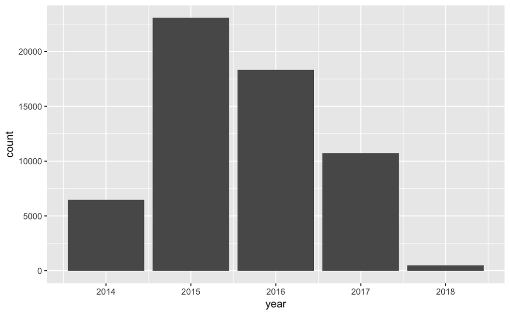

```r
p <- ggplot(search_data, aes(year))
p + geom_bar()
```

#### After determine the years with the largest search volume we can plot monthly searches

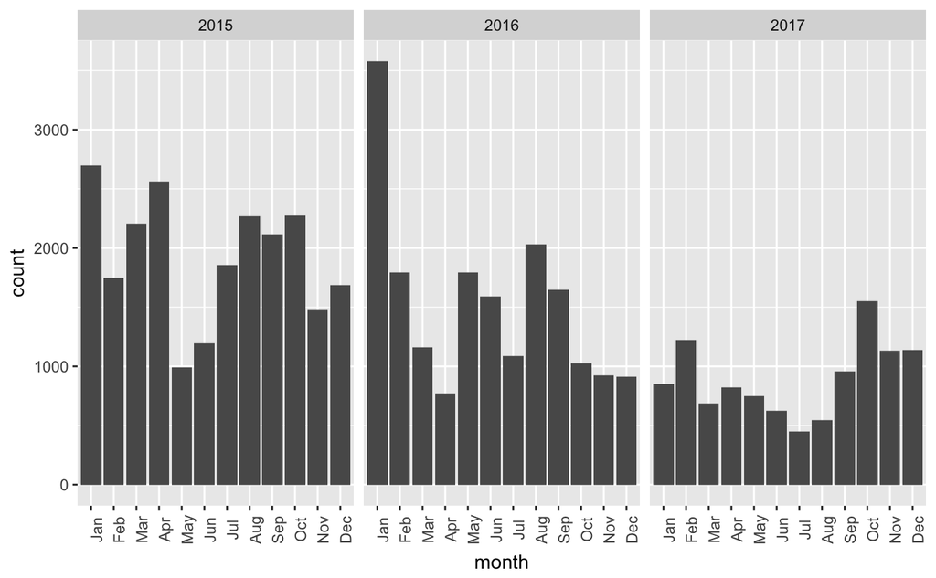

```r
monthly <- search_data[(search_data$year > 2014 & search_data$year< 2018), ]
ggplot(monthly) + geom_bar(aes(x = month, group = year)) +
  theme(axis.text.x = element_text(angle=90)) +
  facet_grid(.~year, scales="free")
```

#### Another interesting metrict is searches by Hour

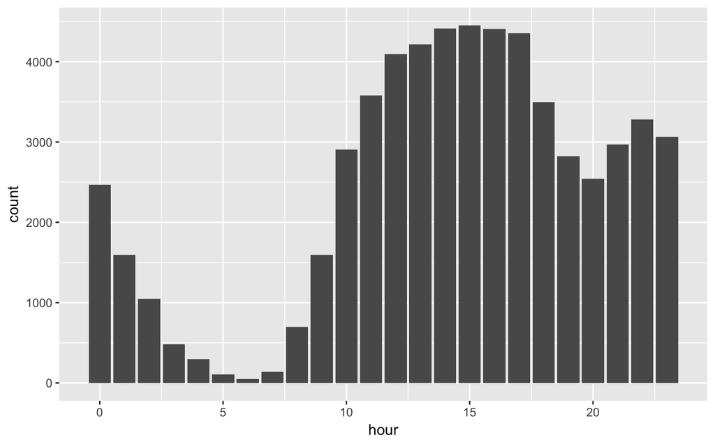

```r
p <- ggplot(search_data, aes(hour))
p + geom_bar()
```

#### We can also plot the search data by day of the week to determine day are the most active

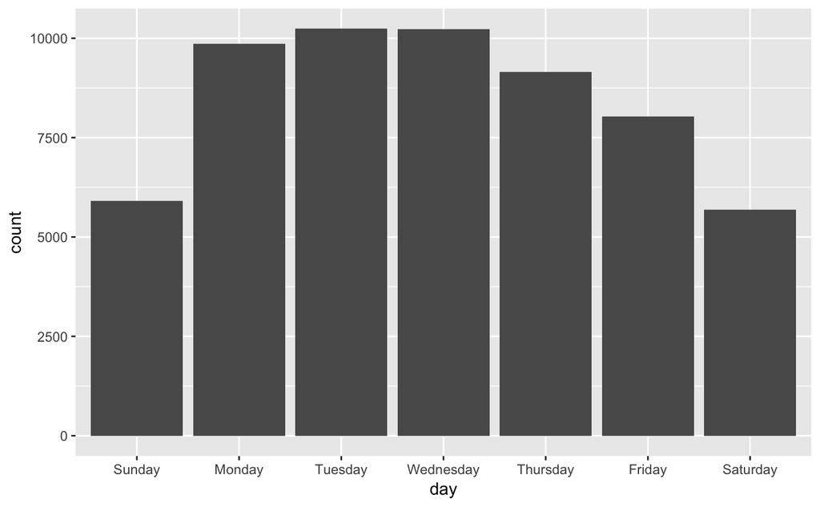

```r
p <- ggplot(search_data, aes(day))
p + geom_bar()
```

#### We can take it an step further and group search time with day of the week.

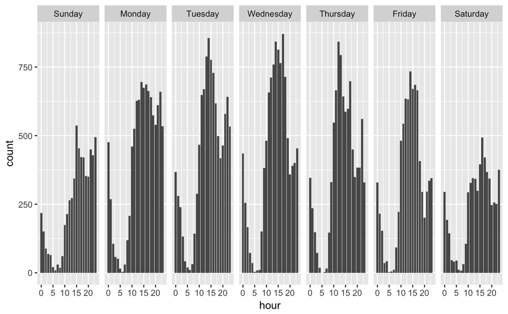

```r
ggplot(search_data) +
  geom_bar(aes(x = hour, group = day) ) +
  facet_grid(.~day, scales = "free")
```

#### We can group the search data by year and day of the week, to visualize the overall trend

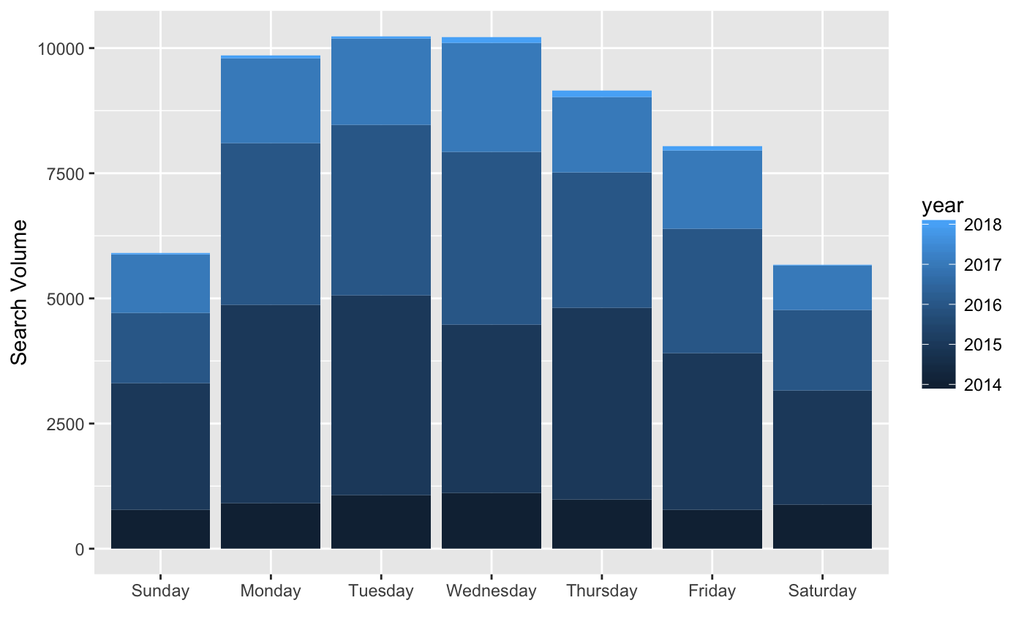

```r
wkday <- group_by(search_data, year, day) %>% summarize(count = n())
p <- ggplot(wkday, aes(day, count, fill = year))
p + geom_bar(stat = "identity") + labs(x = "", y = "Search Volume")
```

## Reporting: A Wordcloud from Google Search Data

#### First we need to extract the text and clean it using regular expressions

```r
search <- tolower(search_data$search)
search <- iconv(search, "ASCII", "UTF-8", " ")
search <- gsub('(http|https)\\S+\\s*|(#|@)\\S+\\s*|\\n|\\"', " ", search)
search <- gsub("(.*.)\\.com(.*.)\\S+\\s|[^[:alnum:]]", " ", search)
search <- trimws(search)
```

#### After cleaning the text we can create a Text Corpus (a large and structured set of texts) and remove some words

```r
search_corpus <-  Corpus(VectorSource(search))
search_corpus <- tm_map(search_corpus, content_transformer(removePunctuation))
search_corpus <- tm_map(search_corpus, content_transformer(removeNumbers))
stopwords <- c(stopwords("english"), "chrome", "chicago", "jlroo", "google")
search_corpus <- tm_map(search_corpus, removeWords, stopwords)
```

#### Now from the corpus we need to create a Term Document Matrix in order to create word associations and a wordcloud

```r
search_tdm <- TermDocumentMatrix(search_corpus)
search_matrix <- as.matrix(search_tdm)
```

#### Using the Term Document matrix we can create a data frame with words and related frequencies

```r
v <- sort(rowSums(search_matrix), decreasing = TRUE)
tw_names <- names(v)
d <- data.frame(word = tw_names, freq = v)
```

#### Set a threshold for the min/max frequency of words to create the wordcloud

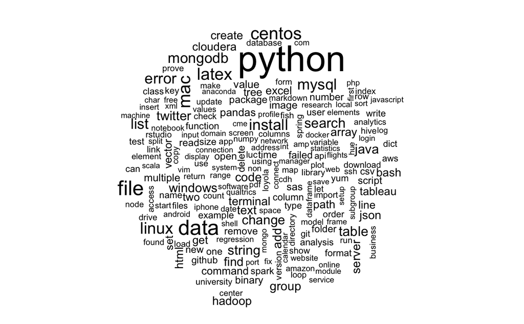

```r
wordcloud(d$word, d$freq, min.freq = 50, scale = c(3 , 0.5), max.words = 200)
```